# Case Study-2 (Aerofit Treadmil)

```python
import pandas as pd
import numpy as np
```

```python
import matplotlib.pyplot as plt
import seaborn as sns
sns.set_theme()
```

```python
!gdown https://d2beiqkhq929f0.cloudfront.net/public_assets/assets/000/001/125/original/aerofit_treadmill.csv
```

```
Downloading...
From: https://d2beiqkhq929f0.cloudfront.net/public_assets/assets/000/001/125/original/aerofit_treadmill.csv
To: C:\Users\Anjali Sharma\Untitled Folder 1\Untitled Folder\aerofit_treadmill.csv
```

```python
data= pd.read_csv('aerofit_treadmill.csv')
data
```

|  | Product | Age | Gender | Education | MaritalStatus | Usage | Fitness | Income | Miles |
| --- | --- | --- | --- | --- | --- | --- | --- | --- | --- |
| 0 | KP281 | 18 | Male | 14 | Single | 3 | 4 | 29562 | 112 |
| 1 | KP281 | 19 | Male | 15 | Single | 2 | 3 | 31836 | 75 |
| 2 | KP281 | 19 | Female | 14 | Partnered | 4 | 3 | 30699 | 66 |
| 3 | KP281 | 19 | Male | 12 | Single | 3 | 3 | 32973 | 85 |
| 4 | KP281 | 20 | Male | 13 | Partnered | 4 | 2 | 35247 | 47 |
| ... | ... | ... | ... | ... | ... | ... | ... | ... | ... |
| 175 | KP781 | 40 | Male | 21 | Single | 6 | 5 | 83416 | 200 |
| 176 | KP781 | 42 | Male | 18 | Single | 5 | 4 | 89641 | 200 |
| 177 | KP781 | 45 | Male | 16 | Single | 5 | 5 | 90886 | 160 |
| 178 | KP781 | 47 | Male | 18 | Partnered | 4 | 5 | 104581 | 120 |
| 179 | KP781 | 48 | Male | 18 | Partnered | 4 | 5 | 95508 | 180 |

180 rows × 9 columns

```python
data.describe()
```

|  | Age | Education | Usage | Fitness | Income | Miles |
| --- | --- | --- | --- | --- | --- | --- |
| count | 180.000000 | 180.000000 | 180.000000 | 180.000000 | 180.000000 | 180.000000 |
| mean | 28.788889 | 15.572222 | 3.455556 | 3.311111 | 53719.577778 | 103.194444 |
| std | 6.943498 | 1.617055 | 1.084797 | 0.958869 | 16506.684226 | 51.863605 |
| min | 18.000000 | 12.000000 | 2.000000 | 1.000000 | 29562.000000 | 21.000000 |
| 25% | 24.000000 | 14.000000 | 3.000000 | 3.000000 | 44058.750000 | 66.000000 |
| 50% | 26.000000 | 16.000000 | 3.000000 | 3.000000 | 50596.500000 | 94.000000 |
| 75% | 33.000000 | 16.000000 | 4.000000 | 4.000000 | 58668.000000 | 114.750000 |
| max | 50.000000 | 21.000000 | 7.000000 | 5.000000 | 104581.000000 | 360.000000 |

# Business Problem

The market research team at AeroFit wants to identify the characteristics of the target audience for each type of treadmill offered by the company, to provide a better recommendation of the treadmills to the new customers. The team decides to investigate whether there are differences across the product with respect to customer characteristics.

Perform descriptive analytics to create a customer profile for each AeroFit treadmill product by developing appropriate tables and charts. For each AeroFit treadmill product, construct two-way contingency tables and compute all conditional and marginal probabilities along with their insights/impact on the business. Dataset

The company collected the data on individuals who purchased a treadmill from the AeroFit stores during the prior three months. The dataset has the following features:

Product Purchased: KP281, KP481, or KP781

Age: In years

Gender: Male/Female

Education: In years

MaritalStatus: Single or partnered

Usage: The average number of times the customer plans to use the treadmill each week.

Income: Annual income (in $)

Fitness: Self-rated fitness on a 1-to-5 scale, where 1 is the poor shape and 5 is the excellent shape.

Miles: The average number of miles the customer expects to walk/run each week

# Product Portfolio:

The KP281 is an entry-level treadmill that sells for $1,500.

The KP481 is for mid-level runners that sell for $1,750.

The KP781 treadmill is having advanced features that sell for $2,500.

```python
data.isna().sum()
```

```
Product          0
Age              0
Gender           0
Education        0
MaritalStatus    0
Usage            0
Fitness          0
Income           0
Miles            0
dtype: int64
```

# Detect outliers

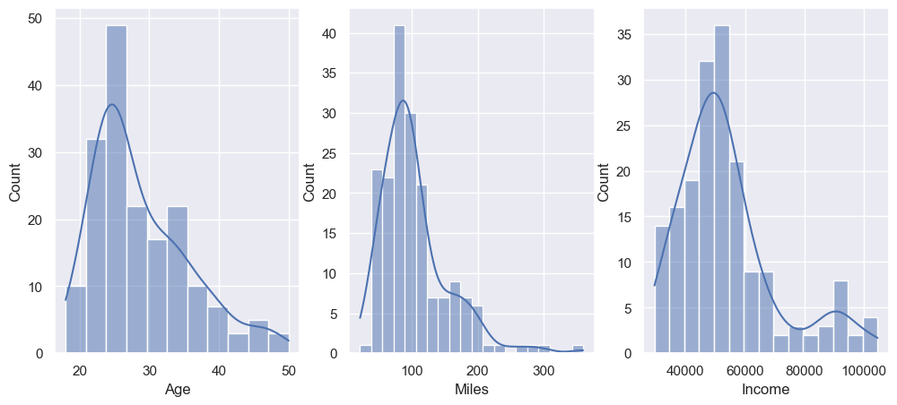

```python
plt.figure(figsize=(12,5))
plt.subplot(1,3,1)
sns.histplot(data['Age'], kde=True)               # Skewed distribution which shows outliers

plt.subplot(1,3,2)
sns.histplot(data['Miles'], kde=True)

plt.subplot(1,3,3)
sns.histplot(data['Income'], kde=True)
plt.show()
```

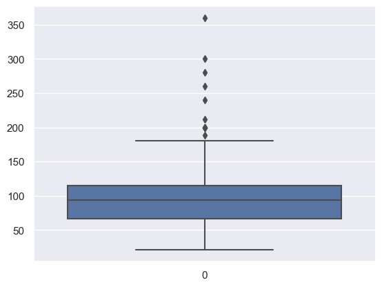

```python
sns.boxplot(data['Miles'])
```

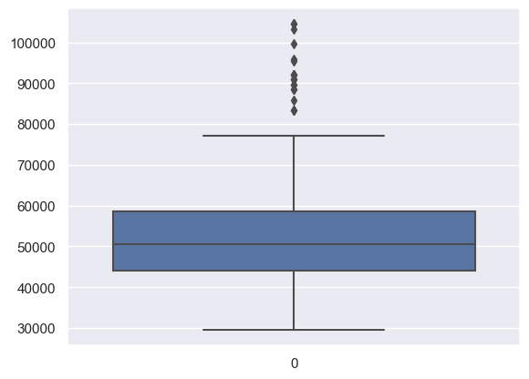

```python
sns.boxplot(data['Income'])
```

```python
data['Miles'].skew()             # right skewed
```

```
1.7244965928707188
```

```python
# Handle outliers
data['Income'].describe()
```

```
count       180.000000
mean      53719.577778
std       16506.684226
min       29562.000000
25%       44058.750000
50%       50596.500000
75%       58668.000000
max      104581.000000
Name: Income, dtype: float64
```

```python
# Finding the IQR
percentile25= data['Income'].quantile(0.25)
percentile75= data['Income'].quantile(0.75)
IQR= percentile75 - percentile25
print(percentile25)
print(percentile75)
print(IQR)

upper_limit= percentile75 + 1.5*IQR
lower_limit= percentile25 - 1.5*IQR
print(upper_limit)
print(lower_limit)
```

```
44058.75
58668.0
14609.25
80581.875
22144.875
```

# Finding Outliers

```python
data[data['Income']>upper_limit].head(3)
```

|  | Product | Age | Gender | Education | MaritalStatus | Usage | Fitness | Income | Miles |
| --- | --- | --- | --- | --- | --- | --- | --- | --- | --- |
| 159 | KP781 | 27 | Male | 16 | Partnered | 4 | 5 | 83416 | 160 |
| 160 | KP781 | 27 | Male | 18 | Single | 4 | 3 | 88396 | 100 |
| 161 | KP781 | 27 | Male | 21 | Partnered | 4 | 4 | 90886 | 100 |

```python
 data[data['Income']<lower_limit]
```

|  | Product | Age | Gender | Education | MaritalStatus | Usage | Fitness | Income | Miles |
| --- | --- | --- | --- | --- | --- | --- | --- | --- | --- |

```python
new_df= data[data['Income']< upper_limit]
new_df
```

|  | Product | Age | Gender | Education | MaritalStatus | Usage | Fitness | Income | Miles |
| --- | --- | --- | --- | --- | --- | --- | --- | --- | --- |
| 0 | KP281 | 18 | Male | 14 | Single | 3 | 4 | 29562 | 112 |
| 1 | KP281 | 19 | Male | 15 | Single | 2 | 3 | 31836 | 75 |
| 2 | KP281 | 19 | Female | 14 | Partnered | 4 | 3 | 30699 | 66 |
| 3 | KP281 | 19 | Male | 12 | Single | 3 | 3 | 32973 | 85 |
| 4 | KP281 | 20 | Male | 13 | Partnered | 4 | 2 | 35247 | 47 |
| ... | ... | ... | ... | ... | ... | ... | ... | ... | ... |
| 156 | KP781 | 25 | Male | 20 | Partnered | 4 | 5 | 74701 | 170 |
| 157 | KP781 | 26 | Female | 21 | Single | 4 | 3 | 69721 | 100 |
| 158 | KP781 | 26 | Male | 16 | Partnered | 5 | 4 | 64741 | 180 |
| 163 | KP781 | 28 | Male | 18 | Partnered | 7 | 5 | 77191 | 180 |
| 165 | KP781 | 29 | Male | 18 | Single | 5 | 5 | 52290 | 180 |

161 rows × 9 columns

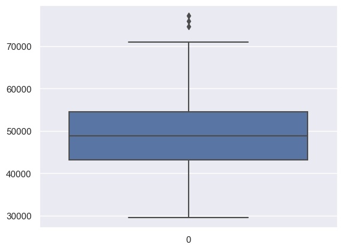

```python
sns.boxplot(new_df['Income'])
```

```python
new_df[new_df['Income']>70000]
```

|  | Product | Age | Gender | Education | MaritalStatus | Usage | Fitness | Income | Miles |
| --- | --- | --- | --- | --- | --- | --- | --- | --- | --- |
| 154 | KP781 | 25 | Male | 18 | Partnered | 6 | 4 | 70966 | 180 |
| 155 | KP781 | 25 | Male | 18 | Partnered | 6 | 5 | 75946 | 240 |
| 156 | KP781 | 25 | Male | 20 | Partnered | 4 | 5 | 74701 | 170 |
| 163 | KP781 | 28 | Male | 18 | Partnered | 7 | 5 | 77191 | 180 |

```python
new_df['Income'].mean()
```

```
49119.1801242236
```

```python
data['Income'].mean()
```

```
53719.57777777778
```

```python
data['Product'].value_counts()
```

```
KP281    80
KP481    60
KP781    40
Name: Product, dtype: int64
```

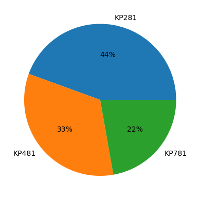

```python
dist= data[['Product']]
dist.groupby(['Product']).value_counts().plot(kind='pie', autopct='%1.0f%%')
```

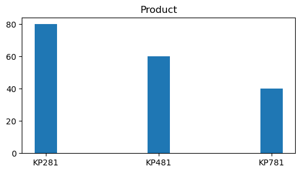

```python
cat_counts= data['Product'].value_counts()
x_bar= cat_counts.index
y_bar= cat_counts

plt.figure(figsize=(6,3))
plt.bar(x_bar, y_bar, width=0.2)
plt.title('Product', fontsize=12)
plt.show()
```

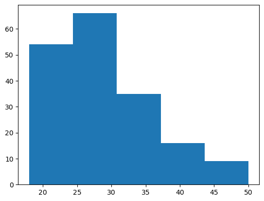

```python
plt.hist(data['Age'],bins=5)
```

# Target Audience

mostly from age 18 to 30, purchase most of our product.

```python
data['Age'].min()
```

```
18
```

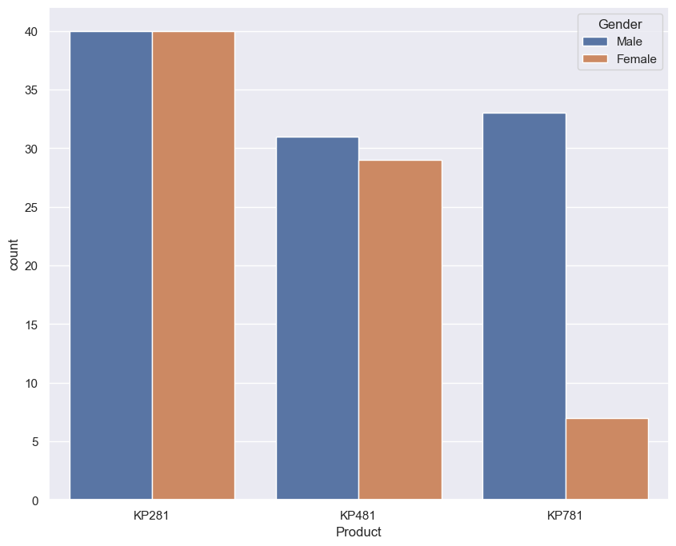

```python
plt.figure(figsize=(10,8))
sns.countplot(x='Product',hue='Gender',data=data)
```